# 02. Data Visualization

## Grammar of Graphics

Data visualization is an incredibly important skill and a task that R is particularly well-designed for. We are going to learn and use the **ggplot2** package for building beautiful and informative graphics. The package makes it easy to build fairly complex graphics in a way that is guided by a general theory of data visualization. The only downside is that, because it is built around a theoretical model rather than many one-off solutions for different tasks, it has a steep initial learning curve. These notes will, hopefully, make this as painless as possible.

The core idea of the grammar of graphics is that visualizations are composed of independent *layers*. To describe a specific layer, we need to specify several elements:

- *data*: the dataset from which data will be taken to construct the plot
- *aes*: a mapping from elements of the plot to columns in our dataset (i.e., the position on the x-axis or the color of our points); it stands for aesthetics
- *geom*: a description of what kinds of objects to plot (i.e., points, labels, or boxes)

You can describe virtually any type of visualization by putting together these elements.

To show how to use the grammar of graphics, we will start by using the food dataset introduced in the previous chapter, with each row describing a particular item of food along with various nutritional information. The first plot we will make is a scatterplot that investigates the relationship between calories and the total fat (in grams) that are in a 100g portion of each food item. In the language of the grammar of graphics we can describe this with the following elements:

- *data*: our dataset is called `food`
- *aes*: the x-axis will be associated with `calories` and the y-axis with `total_fat`
- *geom*: we will build a plot with a points geometry; each row of data is represented by a point

The easiest way to understand how we good these elements within **ggplot** is by seeing an example. Here is the code to specify the data, aes, and geom, along with the output plot:

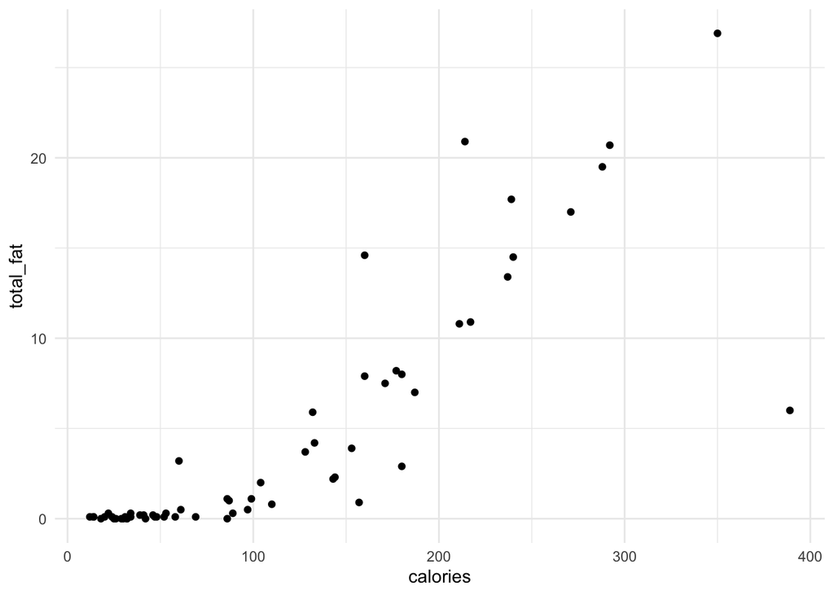

```r
food %>%
  ggplot() +
    geom_point(aes(x = calories, y = total_fat))
```

In the first line we specify the dataset (`food`), which is then piped (`%>%`) into the function `ggplot`, which instructs R to start a new plot. Next, we add (`+`) a layer to the plot. This layer uses a points geom (`geom_point`) and describes two aes values, `x = calories` and `y = total_fat`.

In order to make a similar plot with different variables, or a different dataset, you can copy this code and change the associated variable names (`food`, `calories`, and `total_fat`). In the following sections we will further see how to modify and build on this basic structure to create more complex graphics.

## Text Geometry

Let’s go through several other choices of geometries that we could have in the plot. There are many of these, but in general you can create most plots with only a small number of geometry types. To start, we will use the geometry `geom_text`, which puts a small label in place of the points in our previous example.

The text geometry needs an additional aes called `label` to describe what variable in the dataset should be used as the label. Here, we use the variable called `item` to label each point with the name of the specific food item in question (the column is called `item`):

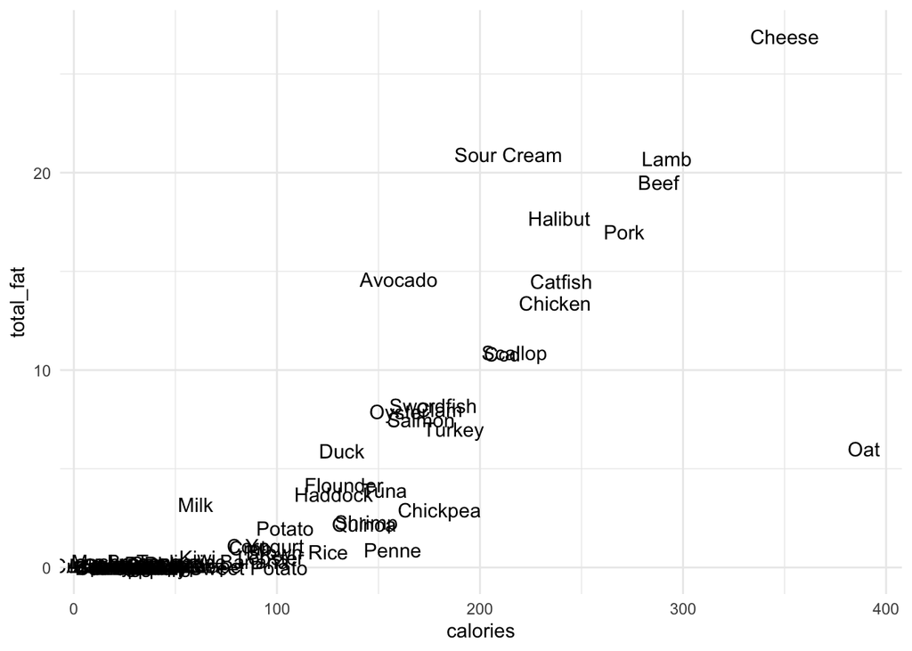

```r
food %>%
  ggplot() +
    geom_text(aes(x = calories, y = total_fat, label = item))
```

Can you now identify what food has the highest amount of fat? Or the highest calorie count? Hopefully! You likely cannot, however, figure out what foods have the lowest amount of fat because the labels become too clumped together. In order to try to address this issue, we can use a slightly different geometry called `geom_text_repel`. It also places labels on the plot, but has logic that avoids intersecting labels. Instead, labels are moved away from the data points and connected (when needed) by a line segment:

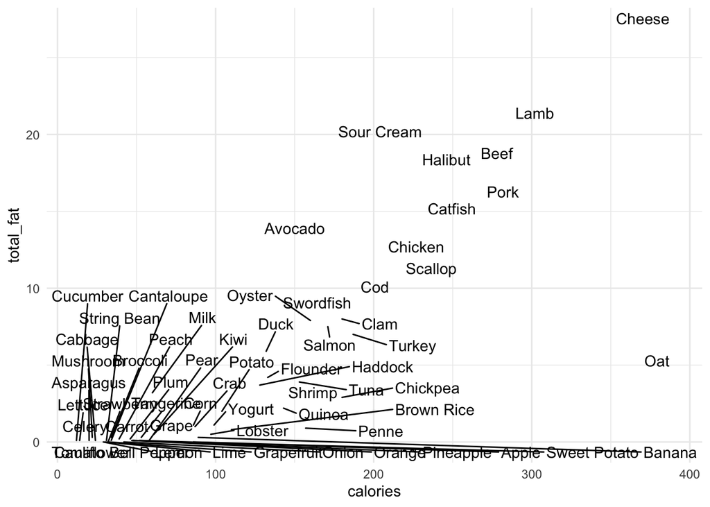

```r
food %>%
  ggplot() +
    geom_text_repel(aes(x = calories, y = total_fat, label = item))
```

This is still a bit busy in the lower left-hand corner, but should be slightly easier to read in the middle of the plot.

## Layering Geometries

Remember that our theory of the grammar of graphics building plots as *layers*. In our two examples so far we have used only a single layer. We can put them together by simply adding geoms together. For example, we can add both the text (repel) layer and the points themselves:

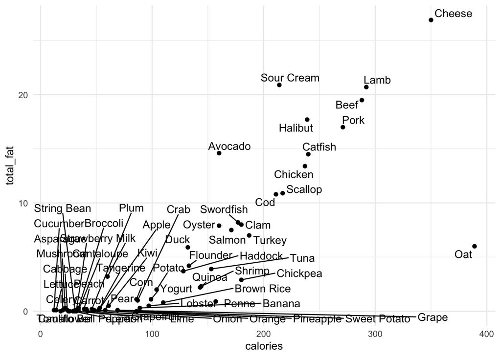

```r
food %>%
  ggplot() +
    geom_point(aes(x = calories, y = total_fat)) +
    geom_text_repel(aes(x = calories, y = total_fat, label = item))
```

You should now see that we have both the labels and the points. Notice that the `geom_text_repel` also makes sure that the labels do not intersect the points themselves.

## Line Geometry

Starting with the code above, let’s modify the dataset and aes values to show the relationship between the year and the price of tea:

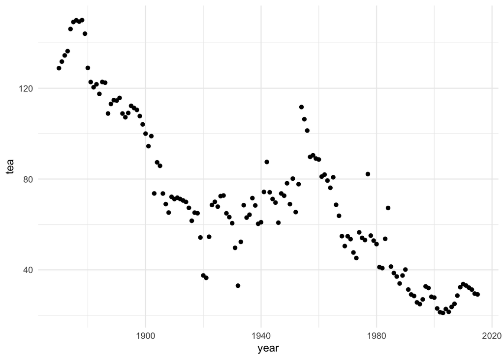

```r
food_prices %>%
  ggplot() +
    geom_point(aes(x = year, y = tea))
```

This is already a great start. However, as we are showing the change of one variables over time, it may be reasonable to use a continuous line over time rather than using the point geometry. To make this kind of plot, we replace the point geom with `geom_line`. Here is what the plot looks like with the points connect as dots:

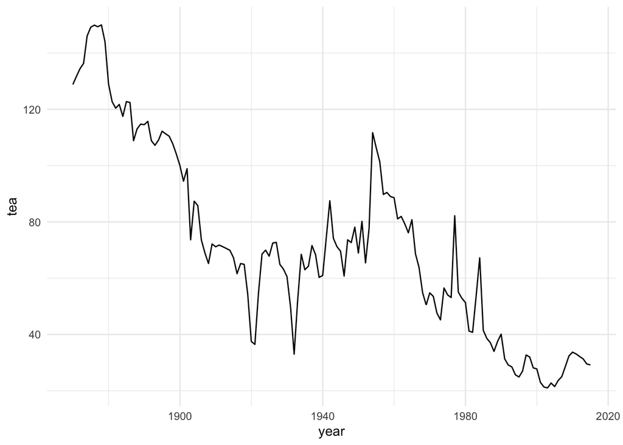

```r
food_prices %>%
  ggplot() +
    geom_line(aes(x = year, y = tea))
```

Do you think that its easier to see the trend over time with the line geom?

## Formatting graphics code

- indent the `ggplot` command by two spaces
- indent every line below `ggplot` by four spaces
- always add each layer of a plot as a new line

As with our original set of style guideliens, you will make your life a lot easier if you get used to these rules right from the start.

## Exercises and References

There is are exercise notebook for this chapter:

- **exercies02A.Rmd**: practice producing graphics for a new dataset
- **exercies02B.Rmd**: open-ended questions to explore with data

It is strongly recommended to complete at least the first notebook prior to continuing on to the next chapter.

We will continue to look at the various components of the Grammar of Graphics in the following chapter, at which point several other references are provided for further study.